# Photosystem II Sustained Function under Low Light and Low Temperatures; Polar vs. Temperate Phytoplankton

# Results

## 1.21 Single Turnover Variable Chlorophyll Fluorescence

Exposing phytoplankton cultures to a series of 32 successive flashes produced oscillations in the maximum quantum yield of photochemistry in PSII, as estimated through the secondary chlorophyll fluorescence parameter F<sub>V</sub>/F<sub>M</sub>. Initially, the majority of the dark-adapted population of PSII is at S1, with a smaller fraction at S0 de Wijn and van Gorkom (2002). As shown in Fig @ref{fig:rep_osc} for the polar alga *Chlamydomonas priscuii*, the time series of F<sub>V</sub>/F<sub>M</sub> over successive flashes reveals consistent variations in fluorescence yield as the predominant S-States follow each other across the PSII within the population. However, the amplitude of the ChlF oscillations declines progressively over time, and with wider spacing of sequential flashes, equivalent to decreasing effective light levels, and is less persistent at a higher measurement temperature

## 1.22 Wavelet Analysis

Wavelet transformations were computed for the fluorescence time series of each unique combination of measurement temperature, flash spacing, growth temperature, and species or strain. Assessing the wavelet power of a 4-step periodicity across conditions, key trends emerge. As exemplified by the Antarctic green alga *Chlamydomonas priscuii* (Figure @ref{fig:cpriscuii_waveletpower}), the average wavelet power declines with increasing flash spacings, equivalent to decreasing effective light levels, and also with increasing measurement temperatures.

[figure not shown]

(#fig:cpriscuii_waveletpower)Sample plot of wavelet powers by period of oscillations in the maximum quantum yield of photochemistry Antarctic green algae *Chlamydomonas priscuii*, grown at 4°C, and measured across a range of measurement temperatures and flash spacings, with the equivalent effective light levels. Regions where wavelet power reached statistical significance (p < 0.05) shaded in blue

In contrast, in the temperate green algae *Chlamydomonas reinhardtii* (Figure @ref{fig:creinhardtiii_waveletpower}), the wavelet power is consistently lower, showing a weaker 4-step periodicity of ChlF in temperate taxa, which only reaches statistical significance at shorter flash spacings, with higher equivalent effective light levels.

[figure not shown]

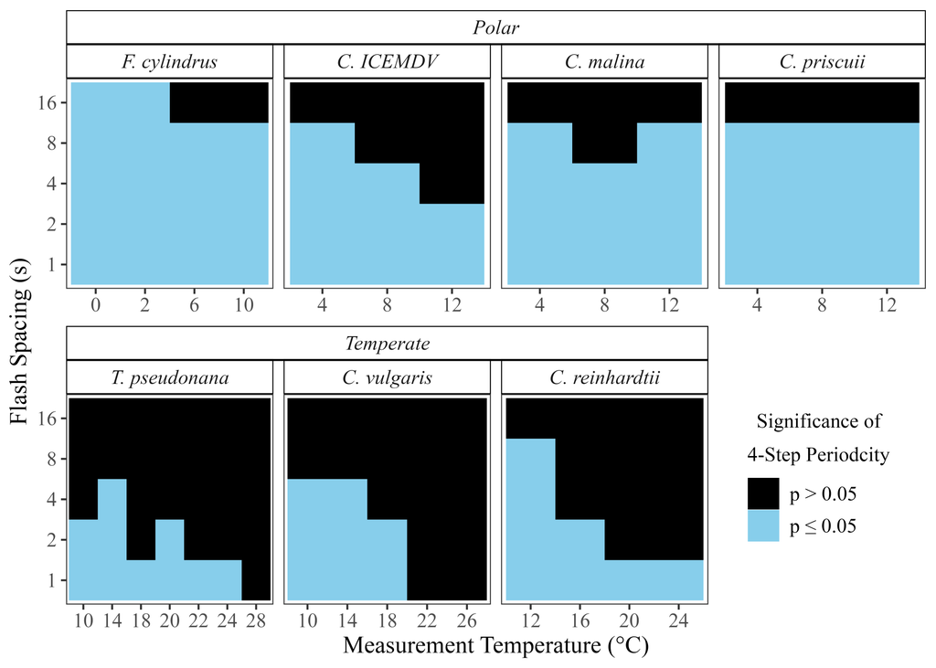

(#fig:periodicity_mtrx)Statistical significance of 4-step oscillations in the maximum quantum yield of PSII photochemistry across polar and temperate phytoplankton taxa, as measured through variable chlorophyll fluorescence. Measurement conditions where wavelet power for 4-step periodicity reached statistical significance (p < 0.05) shaded in blue

## 1.23 Generalized Additive Modelling by Difference from Growth Temperature

[figure not shown]

(#fig:diatoms_gamdiff)GAM models for polar and temperate diatoms, of consecutive flashes before damping of S-State-induced chlorophyll fluorescence oscillations. GAM model predicted by the difference from growth temperature (Δ°C) during measurements and the effective light level (µmol photons m<sup>-2</sup>s<sup>-1</sup>, estimated from flash spacings in seconds). White dashed vertical lines represent the growth temperatures.

## 1.24 Generalized Additive Modelling By Measurement Temperature

[figure not shown]

(#fig:diatoms_gamtemp)GAM models for polar and temperate diatoms, of consecutive flashes before damping of S-State-induced chlorophyll fluorescence oscillations. GAM model predicted by the temperature (°C) imposed during measurements and the effective light level (µmol photons m<sup>-2</sup>s<sup>-1</sup>, estimated from flash spacings in seconds). White dashed vertical lines represent the growth temperatures.

[figure not shown]

# Discussion

## 1.26 Ecological Implications & Future Directions

Unravelling the mechanisms enabling polar phytoplankton to sustain slow, but significant productivity under the ice in the winter is crucial for predicting the changing dynamics of spring phytoplankton blooms, in the face of rapid warming (Ardyna and Arrigo, 2020). Beyond direct temperature changes, polar aquatic ecosystems are experiencing reductions in sea ice extent and thickness, escalating freshwater inputs, acidification, and increased winds and storms Cvetkovska et al. (2022). These pressures are causing alterations in the productivity and seasonal peaks of phytoplankton blooms Croteau et al. (2021). Understanding the nature of maintaining an intact photosystem under the ice in the winter allows us to better predict under what conditions these blooms will initiate, and which phytoplankton strains will be involved (Hancke et al., 2018). The ability to maintain efficient photosynthetic energy conversion over winter is crucial for the timing and speed of spring bloom initiation (Hancke et al., 2018). Strains with this ability may possess a competitive advantage in quickly initiating spring growth, giving them first access to the nutrients required to form an extensive bloom. Thus, the proportions of these strains may increase in polar regions. Altering the phytoplankton community composition may, in turn, exert bottom-up effects on polar ecosystems (Ardyna and Arrigo, 2020). Future directions for this research include more extensive comparative analyses to further our understanding. Incorporating more strains of diatoms and green algae, as well as other phytoplankton groups will enable us to uncover whether certain groups have a higher capacity to suppress energetically wasteful charge recombinations. A difference between these groups may affect their contribution to the phytoplankton community, leading to differences in the ecosystem services offered by spring phytoplankton blooms. Moreover, since there were differences observed between *Fragilariopsis cylindrus* strains grown at 0 and 6 °C, further comparison between ecotypes may yield information on the conditions that lead to the evolution of this ability.

# References

Ardyna, M., and Arrigo, K. R. (2020). Phytoplankton dynamics in a changing Arctic Ocean. *Nature Climate Change* 10, 892–903. doi:10.1038/s41558-020-0905-y.

Balzano, S., Gourvil, P., Siano, R., Chanoine, M., Marie, D., Lessard, S., Sarno, D., and Vaulot, D. (2012). Diversity of cultured photosynthetic flagellates in the northeast Pacific and Arctic Oceans in summer. *Biogeosciences* 9, 4553–4571. doi:10.5194/bg-9-4553-2012.

Bayer-Giraldi, M., Weikusat, I., Besir, H., and Dieckmann, G. (2011). Characterization of an antifreeze protein from the polar diatom Fragilariopsis cylindrus and its relevance in sea ice. *Cryobiology* 63, 210–219. doi:10.1016/j.cryobiol.2011.08.006.

Cazelles, B., Chavez, M., Berteaux, D., Ménard, F., Vik, J. O., Jenouvrier, S., and Stenseth, N. C. (2008). Wavelet analysis of ecological time series. *Oecologia* 156, 287–304. doi:10.1007/s00442-008-0993-2.

Cefarelli, A. O., Ferrario, M. E., Almandoz, G. O., Atencio, A. G., Akselman, R., and Vernet, M. (2010). Diversity of the diatom genus Fragilariopsis in the Argentine Sea and Antarctic waters: Morphology, distribution and abundance. *Polar Biology* 33. doi:10.1007/s00300-010-0794-z.

Cook, G., Teufel, A., Kalra, I., Li, W., Wang, X., Priscu, J., and Morgan-Kiss, R. (2019). The Antarctic psychrophiles Chlamydomonas spp. UWO241 and ICEMDV exhibit differential restructuring of photosystem I in response to iron. *Photosynthesis Research* 141, 209–228. doi:10.1007/s11120-019-00621-0.

Croteau, D., Guérin, S., Bruyant, F., Ferland, J., Campbell, D. A., Babin, M., and Lavaud, J. (2021). Contrasting nonphotochemical quenching patterns under high light and darkness aligns with light niche occupancy in Arctic diatoms. *Limnology and Oceanography* 66, S231–S245. doi:10.1002/lno.11587.

Cvetkovska, M., Vakulenko, G., Smith, D. R., Zhang, X., and Hüner, N. P. A. (2022). Temperature stress in psychrophilic green microalgae: Minireview. *Physiologia Plantarum* 174, e13811. doi:10.1111/ppl.13811.

Dau, H., and Haumann, M. (2007). Time-resolved X-ray spectroscopy leads to an extension of the classical S-state cycle model of photosynthetic oxygen evolution. *Photosynthesis Research* 92, 327–343. doi:10.1007/s11120-007-9141-9.

de Wijn, R., and van Gorkom, H. J. (2002). S-state dependence of the miss probability in Photosystem II. *Photosynthesis Research* 72, 217–222. doi:10.1023/A:1016128632704.

Gates, C., Ananyev, G., and Dismukes, G. C. (2020). Realtime kinetics of the light driven steps of photosynthetic water oxidation in living organisms by “stroboscopic” fluorometry. *Biochimica et Biophysica Acta (BBA) - Bioenergetics* 1861, 148212. doi:10.1016/j.bbabio.2020.148212.

Han, G., Chernev, P., Styring, S., Messinger, J., and Mamedov, F. (2022). Molecular basis for turnover inefficiencies (misses) during water oxidation in photosystem II. *Chemical Science* 13, 8667–8678. doi:10.1039/D2SC00854H.

Han, G., Ho, F. M., Havelius, K. G. V., Morvaridi, S. F., Mamedov, F., and Styring, S. (2008). Direct quantification of the four individual S states in Photosystem II using EPR spectroscopy. *Biochimica et Biophysica Acta (BBA) - Bioenergetics* 1777, 496–503. doi:10.1016/j.bbabio.2008.03.007.

Han, G., Mamedov, F., and Styring, S. (2012). Misses during water oxidation in photosystem II are S state-dependent. *The Journal of Biological Chemistry* 287, 13422–13429. doi:10.1074/jbc.M112.342543.

Hancke, K., Lund-Hansen, L. C., Lamare, M. L., Højlund Pedersen, S., King, M. D., Andersen, P., and Sorrell, B. K. (2018). Extreme Low Light Requirement for Algae Growth Underneath Sea Ice: A Case Study From Station Nord, NE Greenland. *Journal of Geophysical Research: Oceans* 123, 985–1000. doi:10.1002/2017JC013263.

Hoppe, C. J. M., Fuchs, N., Notz, D., Anderson, P., Assmy, P., Berge, J., Bratbak, G., Guillou, G., Kraberg, A., Larsen, A., et al. (2024). Photosynthetic light requirement near the theoretical minimum detected in Arctic microalgae. *Nature Communications* 15, 7385. doi:10.1038/s41467-024-51636-8.

Hüner, N. P. A., Szyszka-Mroz, B., Ivanov, A. G., Kata, V., Lye, H., and Smith, D. R. (2023). Photosynthetic adaptation and multicellularity in the Antarctic psychrophile, Chlamydomonas priscuii. *Algal Research* 74, 103220. doi:10.1016/j.algal.2023.103220.

Ivanov, A. G., Sane, P. V., Krol, M., Gray, G. R., Balseris, A., Savitch, L. V., Öquist, G., and Hüner, N. P. A. (2006). Acclimation to temperature and irradiance modulates PSII charge recombination. *FEBS Letters* 580, 2797–2802. doi:10.1016/j.febslet.2006.04.018.

Ivanov, A. G., Sane, P., Hurry, V., Król, M., Sveshnikov, D., Huner, N. P. A., and Öquist, G. (2003). Low-temperature modulation of the redox properties of the acceptor side of photosystem II: Photoprotection through reaction centre quenching of excess energy. *Physiologia Plantarum* 119, 376–383. doi:10.1034/j.1399-3054.2003.00225.x.

Kang, S.-H., and Fryxell, G. A. (1992). Fragilariopsis cylindrus (Grunow) Krieger: The most abundant diatom in water column assemblages of Antarctic marginal ice-edge zones. *Polar Biology* 12, 609–627. doi:10.1007/BF00236984.

Keren, N., Berg, A., van Kan, P. J. M., Levanon, H., and Ohad, I. (1997). Mechanism of photosystem II photoinactivation and D1 protein degradation at low light: The role of back electron flow. *Proceedings of the National Academy of Sciences* 94, 1579–1584. doi:10.1073/pnas.94.4.1579.

Kirk, J. T. O. (2011). *Light and Photosynthesis in Aquatic Ecosystems*. 3rd ed. Cambridge, UK: Cambridge University Press.

Kolber, Z. S. (1998). Measurements of variable chlorophyll fluorescence using fast repetition rate techniques: Defining methodology and experimental protocols. *Biochimica et Biophysica Acta* 1367, 19. doi:10.1016/S0005-2728(98)00135-2.

Laloi, C., Przybyla, D., and Apel, K. (2006). A genetic approach towards elucidating the biological activity of different reactive oxygen species in Arabidopsis thaliana. *Journal of Experimental Botany* 57, 1719–1724. doi:10.1093/jxb/erj183.

Leu, E., Mundy, C. J., Assmy, P., Campbell, K., Gabrielsen, T. M., Gosselin, M., Juul-Pedersen, T., and Gradinger, R. (2015). Arctic spring awakening – Steering principles behind the phenology of vernal ice algal blooms. *Progress in Oceanography* 139, 151–170. doi:10.1016/j.pocean.2015.07.012.

Leyva, L. A., Bashan, Y., Mendoza, A., and de-Bashan, L. E. (2014). Accumulation fatty acids of in Chlorella vulgaris under heterotrophic conditions in relation to activity of acetyl-CoA carboxylase, temperature, and co-immobilization with Azospirillum brasilense. *Naturwissenschaften* 101, 819–830. doi:10.1007/s00114-014-1223-x.

Li, W., Podar, M., and Morgan-Kiss, R. M. (2016). Ultrastructural and Single-Cell-Level Characterization Reveals Metabolic Versatility in a Microbial Eukaryote Community from an Ice-Covered Antarctic Lake. *Applied and Environmental Microbiology* 82, 3659–3670. doi:10.1128/AEM.00478-16.

Lyon, B. R., and Mock, T. (2014). Polar Microalgae: New Approaches towards Understanding Adaptations to an Extreme and Changing Environment. *Biology* 3, 56–80. doi:10.3390/biology3010056.

Mock, T., Otillar, R. P., Strauss, J., McMullan, M., Paajanen, P., Schmutz, J., Salamov, A., Sanges, R., Toseland, A., Ward, B. J., et al. (2017). Evolutionary genomics of the cold-adapted diatom Fragilariopsis cylindrus. *Nature* 541, 536–540. doi:10.1038/nature20803.

Morales-Sánchez, D., Schulze, P. S. C., Kiron, V., and Wijffels, R. H. (2020). Temperature-Dependent Lipid Accumulation in the Polar Marine Microalga Chlamydomonas malina RCC2488. *Frontiers in Plant Science* 11. doi:10.3389/fpls.2020.619064.

Mukhopadhyay, S., Mandal, S. K., Bhaduri, S., and Armstrong, W. H. (2004). Manganese Clusters with Relevance to Photosystem II. *Chemical Reviews* 104, 3981–4026. doi:10.1021/cr0206014.

Otte, A., Winder, J. C., Deng, L., Schmutz, J., Jenkins, J., Grigoriev, I. V., Hopes, A., and Mock, T. (2023). The diatom Fragilariopsis cylindrus: A model alga to understand cold-adapted life. *Journal of Phycology* 59, 301–306. doi:10.1111/jpy.13325.

Pierella Karlusich, J. J., Ibarbalz, F. M., and Bowler, C. (2020). Phytoplankton in the Tara Ocean. *Annual Review of Marine Science* 12, 233–265. doi:10.1146/annurev-marine-010419-010706.

Pinilla, J., and Negrín, M. (2021). Non-Parametric Generalized Additive Models as a Tool for Evaluating Policy Interventions. *Mathematics* 9, 299. doi:10.3390/math9040299.

Posit team (2025). *RStudio: Integrated development environment for R*. Boston, MA: Posit Software, PBC.

Poulsen, N., and Kröger, N. (2023). Thalassiosira pseudonana (Cyclotella nana) (Hustedt) Hasle et Heimdal (Bacillariophyceae): A genetically tractable model organism for studying diatom biology, including biological silica formation. *Journal of Phycology* 59, 809–817. doi:10.1111/jpy.13362.

R Core Team (2023). *R: A language and environment for statistical computing*. Vienna, Austria: R Foundation for Statistical Computing.

Randelhoff, A., Lacour, L., Marec, C., Leymarie, E., Lagunas, J., Xing, X., Darnis, G., Penkerc’h, C., Sampei, M., Fortier, L., et al. (2020). Arctic mid-winter phytoplankton growth revealed by autonomous profilers. *Science Advances* 6, eabc2678. doi:10.1126/sciadv.abc2678.

Rappaport, F., Cuni, A., Xiong, L., Sayre, R., and Lavergne, J. (2005). Charge Recombination and Thermoluminescence in Photosystem II. *Biophysical Journal* 88, 1948–1958. doi:10.1529/biophysj.104.050237.

Rappaport, F., Guergova-Kuras, M., Nixon, P. J., Diner, B. A., and Lavergne, J. (2002). Kinetics and Pathways of Charge Recombination in Photosystem II. *Biochemistry* 41, 8518–8527. doi:10.1021/bi025725p.

Raven, J. A., Kübler, J. E., and Beardall, J. (2000). Put out the light, and then put out the light. *Journal of the Marine Biological Association of the United Kingdom* 80, 1–25. doi:10.1017/S0025315499001526.

Robinson, D. H., Arrigo, K. R., Iturriaga, R., and Sullivan, C. W. (1995). Microalgal Light-Harvesting in Extreme Low-Light Environments in Mcmurdo Sound, Antarctica. *Journal of Phycology* 31, 508–520. doi:10.1111/j.1529-8817.1995.tb02544.x.

Robinson, D., Hayes, A., and Couch, S. (2024). *Broom: Convert statistical objects into tidy tibbles*. Available at: https://broom.tidymodels.org/.

Rutherford, A. W., Osyczka, A., and Rappaport, F. (2012). Back-reactions, short-circuits, leaks and other energy wasteful reactions in biological electron transfer: Redox tuning to survive life in O2. *FEBS Letters* 586, 603–616. doi:10.1016/j.febslet.2011.12.039.

Sane, P. V., Ivanov, A. G., Hurry, V., Huner, N. P. A., and Öquist, G. (2003). Changes in the Redox Potential of Primary and Secondary Electron-Accepting Quinones in Photosystem II Confer Increased Resistance to Photoinhibition in Low-Temperature-Acclimated Arabidopsis. *Plant Physiology* 132, 2144–2151. doi:10.1104/pp.103.022939.

Sane, P. V., Ivanov, A. G., Sveshnikov, D., Huner, N. P. A., and Oquist, G. (2002). A Transient Exchange of the Photosystem II Reaction Center Protein D1:1 with D1:2 during Low Temperature Stress ofSynechococcus sp. PCC 7942 in the Light Lowers the Redox Potential of QB*. *Journal of Biological Chemistry* 277, 32739–32745. doi:10.1074/jbc.M200444200.

Sasso, S., Stibor, H., Mittag, M., and Grossman, A. R. (2018). From molecular manipulation of domesticated Chlamydomonas reinhardtii to survival in nature. *eLife* 7, e39233. doi:10.7554/eLife.39233.

Schoenig, D., Maynard, L., Brice, M.-H., Cazelles, K., Braga, P. H. P., Gongora, E., Sherin, L., Pedersen, E., Taranu, Z., Dussault, C. F., et al. (2023). *Workshop 8: Generalized additive models in R*. Québec Centre for Biodiversity Science.

Schuback, N., Tortell, P. D., Berman-Frank, I., Campbell, D. A., Ciotti, A., Courtecuisse, E., Erickson, Z. K., Fujiki, T., Halsey, K., Hickman, A. E., et al. (2021). Single-Turnover Variable Chlorophyll Fluorescence as a Tool for Assessing Phytoplankton Photosynthesis and Primary Productivity: Opportunities, Caveats and Recommendations. *Frontiers in Marine Science* 8. doi:10.3389/fmars.2021.690607.

Shen, J.-R. (2021). “Photosynthesis Photosystem II: Protein Components, Structure and Electron Transfer,” in *Encyclopedia of Biological Chemistry III (Third Edition)*, ed. J. Jez (Oxford: Elsevier), 215–228. doi:10.1016/B978-0-12-819460-7.00012-8.

Stahl-Rommel, S., Kalra, I., D’Silva, S., Hahn, M. M., Popson, D., Cvetkovska, M., and Morgan-Kiss, R. M. (2022). Cyclic electron flow (CEF) and ascorbate pathway activity provide constitutive photoprotection for the photopsychrophile, Chlamydomonas sp. UWO 241 (renamed Chlamydomonas priscuii). *Photosynthesis Research* 151, 235–250. doi:10.1007/s11120-021-00877-5.

Theis, F. J., and Meyer-Bäse, A. (2010). “Spectral Transformations,” in *Biomedical Signal Analysis : Contemporary Methods and Applications* The MIT Press Series. (MIT Press), 42.

Vass, I. (2011). Role of charge recombination processes in photodamage and photoprotection of the photosystem II complex. *Physiologia Plantarum* 142, 6–16. doi:10.1111/j.1399-3054.2011.01454.x.

Vass, I., and Cser, K. (2009). Janus-faced charge recombinations in photosystem II photoinhibition. *Trends in Plant Science* 14, 200–205. doi:10.1016/j.tplants.2009.01.009.

Vinyard, D. J., Ananyev, G. M., and Charles Dismukes, G. (2013). Photosystem II: The Reaction Center of Oxygenic Photosynthesis. *Annual Review of Biochemistry* 82, 577–606. doi:10.1146/annurev-biochem-070511-100425.

Wickham, H. (2023). *Tidyverse: Easily install and load the tidyverse*. Available at: https://tidyverse.tidyverse.org.

Wiel, J. B. V., D. Mikulicz, J., R. Boysen, M., Hashemi, N., Kalgren, P., M. Nauman, L., J. Baetzold, S., G. Powell, G., He, Q., and Nastaran Hashemi, N. (2017). Characterization of Chlorella vulgaris and Chlorella protothecoides using multi-pixel photon counters in a 3D focusing optofluidic system. *RSC Advances* 7, 4402–4408. doi:10.1039/C6RA25837A.

Wood, S. N. (2017). *Generalized Additive Models: An introduction with R*. 2nd ed. New York: Chapman and Hall/CRC.

Xie, B., Bishop, S., Stessman, D., Wright, D., Spalding, M. H., and Halverson, L. J. (2013). Chlamydomonas reinhardtii thermal tolerance enhancement mediated by a mutualistic interaction with vitamin B12-producing bacteria. *The ISME Journal* 7, 1544–1555. doi:10.1038/ismej.2013.43.

Xie, Y. (2025). *Knitr: A general-purpose package for dynamic report generation in r*. Available at: https://yihui.org/knitr/.

Xu, K., Lavaud, J., Perkins, R., Austen, E., Bonnanfant, M., and Campbell, D. A. (2018). Phytoplankton $\sigma$PSII and Excitation Dissipation; Implications for Estimates of Primary Productivity. *Frontiers in Marine Science* 5. doi:10.3389/fmars.2018.00281.

Yager, R. M. (1998). Detecting influential observations in nonlinear regression modeling of groundwater flow. *Water Resources Research* 34, 1623–1633. doi:10.1029/98WR01010.

Zaharieva, I., and Dau, H. (2019). Energetics and Kinetics of S-State Transitions Monitored by Delayed Chlorophyll Fluorescence. *Frontiers in Plant Science* 10.

Zhu, H. (2024). *kableExtra: Construct complex table with kable and pipe syntax*. Available at: http://haozhu233.github.io/kableExtra/.